# Auswertung TC Daten

## 1.2 MBR vs. noMBR

- Boxplot: Mit MBR können teilweise bis zu 4x mehr Proteine gefunden werden als bei Nichtverwendung von MBR. Die Unterschiede zwischen Razor bzw. Unique sind gering.
- klar ist eine Abhänigkeit von der Gesamtanzahl an gefundenen Proteinen ersichtlich
- ab ca. 350 gefundenen Proteinen bleiben die mehr gefundenen Proteinen auf einem ähnlichen Level
- darunter steigt die Anzahl der gefundenen Proteine mit MBR dramatatisch an wenn sich die Gesamtanzahl an Proteinen reduziert
- dies ist unabhängig ob Razor oder Unique verwendet wird

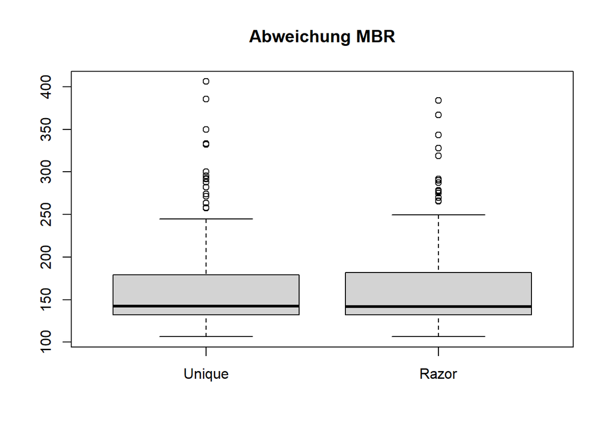

```r
#MBR evaluation
unique <- (data$Unique.MBR.2.peptides/data$Unique.no.MBR.2.peptides)*100
razor <- (data$Razor.MBR.2.peptides/data$Razor.noMBR.2.peptides)*100

boxplot(unique,razor, main = "Abweichung MBR", names = c("Unique", "Razor"))
```

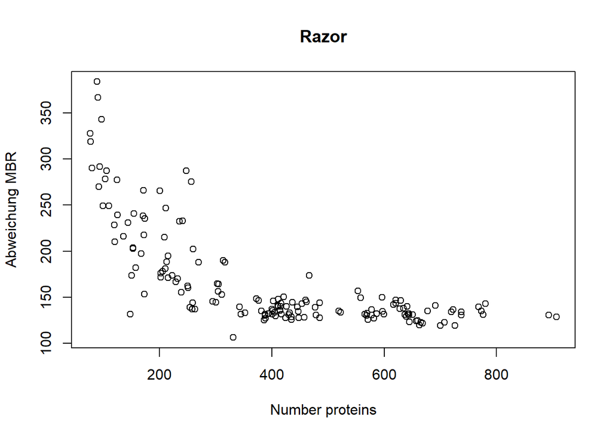

```r
mean_unique <- (data$Unique.MBR.2.peptides+data$Unique.no.MBR.2.peptides)/2
mean_razor <- (data$Razor.noMBR.2.peptides+data$Razor.MBR.2.peptides)/2

plot(mean_razor,razor, xlab= "Number proteins", ylab="Abweichung MBR", main = "Razor")
```

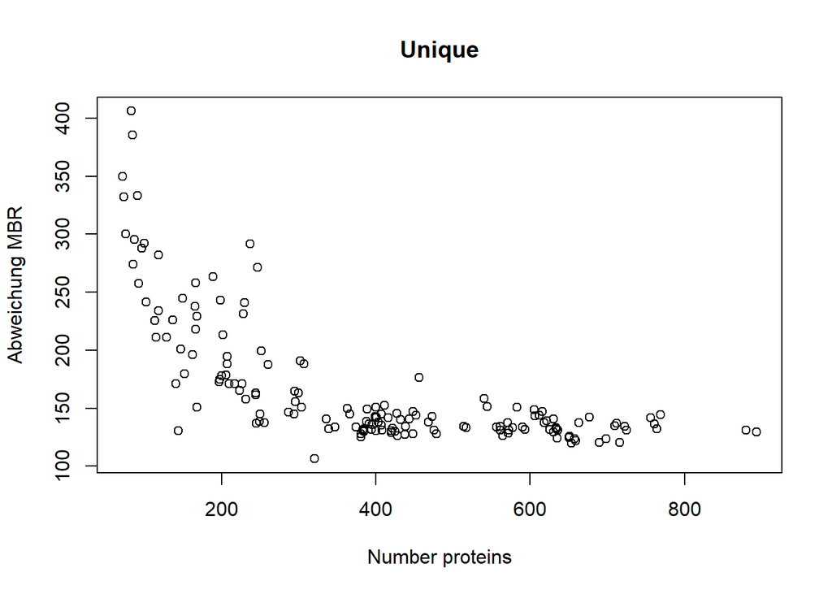

```r
plot(mean_unique,unique, xlab= "Number proteins", ylab="Abweichung MBR", main="Unique")
```

## 1.3 Razor-LFQ

- mit Razor werden im Median 6% mehr Proteine gefunden wenn MBR verwendet wird
- bei noMBR sind es 11%
- es zeigt sich, dass der Unterschied Razor/LFQ nicht von der Anzahl der gefundenen Proteine abhängt

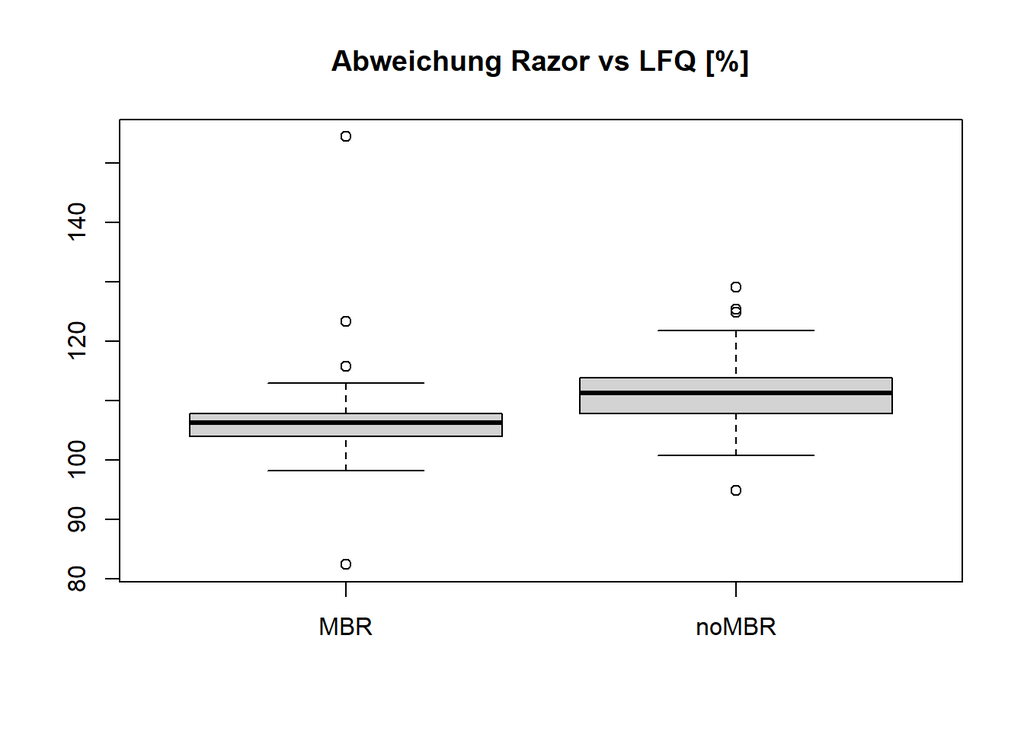

```r
data <- read.csv("Extraktionen_gesamt_V2_DL.csv", sep=";")
# unique vs razor
MBR <- (data$Razor.MBR.2.peptides/data$LFQ.MBR)*100
noMBR <- (data$Razor.noMBR.2.peptides/data$LFQ.noMBR)*100

boxplot(MBR, noMBR, main = "Abweichung Razor vs LFQ [%]", names = c("MBR", "noMBR"))
```

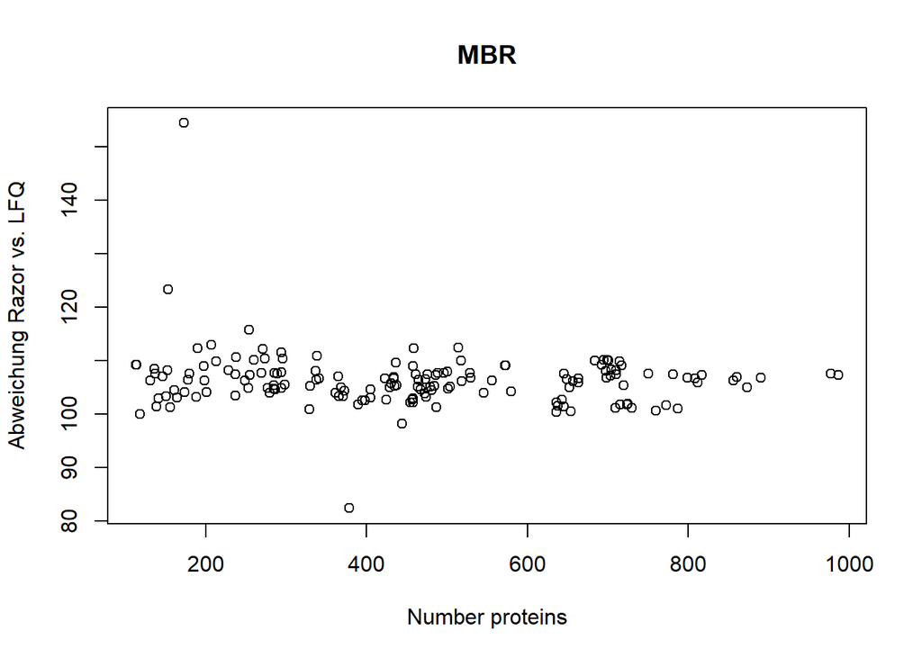

```r
mean_MBR <- (data$Razor.MBR.2.peptides+data$LFQ.MBR)/2
mean_noMBR <- (data$Razor.noMBR.2.peptides+data$LFQ.noMBR)/2

plot(mean_MBR,MBR, xlab= "Number proteins", ylab="Abweichung Razor vs. LFQ", main = "MBR")
```

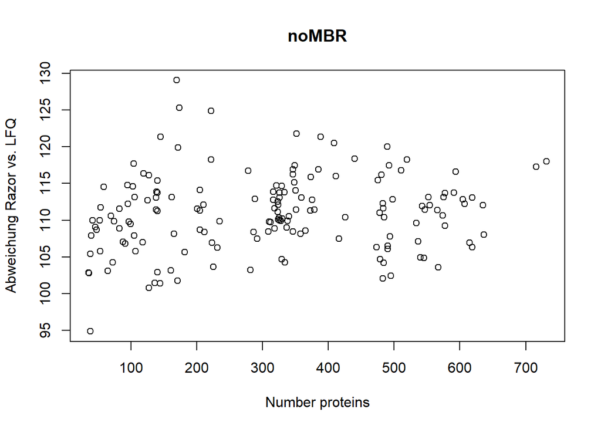

```r
plot(mean_noMBR,noMBR, xlab= "Number proteins", ylab="Abweichung Razor vs. LFQ", main = "noMBR")
```

```r
#t.test(data$Razor.noMBR.2.peptides,data$Unique.no.MBR.2.peptides,paired = TRUE)
#t.test(data$Razor.MBR.2.peptides,data$Unique.MBR.2.peptides,paired = TRUE)
```